# Consulta COVID-19

[VERSÃO HTML](http://htmlpreview.github.io/?https://github.com/transparencia-mg/especificacoes-portal-transparencia/blob/feat/consulta-contratos-covid/consulta-contratos-covid.html)

# Visão geral da Demanda

(inicio)

Essa demanda visa implementar uma seção exclusiva no Portal da Transparência para divulgar dados referentes à COVID-19.A seção irá disponibilizar as seguintes consultas:

- Compras emergenciais
- Compras - Programa de Enfrentamento Covid-19
- Legislação e Normativos
- Dados abertos;
- Ouvidoria
- Acesso à Informação
- Conselho de Transparência e Combate a Corrupção
- Dados Epidemiológicos
- Doações
- Medidas de estímulo econômico e proteção social

# Motivação

(inicio)

Com foco no fomento da transparência e melhores práticas para atender ao cidadão, o Estado de Minas Gerais disponibiliza sessão específica para facilitar ainda mais a divulgação de dados relacionados ao enfretamento a pandemia causada pela COVID-19.

A iniciativa reforça o compromisso com a transparência, enquanto diretriz de governo, e abre mais uma possibilidade para o cidadão exercer seu papel no controle social.

# Especificação

(inicio)

## Página Inicial

(inicio)

Para contemplar a inclusão dos modos de consulta relacionadas a COVID-19 a página inicial do Portal deve ser:

[figure not shown]

**Texto do ícone COVID-19:** Encontre aqui os gastos, contratações e legislações do Estado referente ao enfretamento à pandemia causada pela COVID-19.

#### Observação

O ícone *[COVID-19]* deve se o primeiro ícone da esquerda para direita, sendo os demais reposicionados. O ícone *[TCE/Obras Públicas]* deverá ficar abaixo do ícone *[Munícipios]*

## Página das Consultas

(inicio)

Após clicar no ícone *[COVID-19]* deve ser apresentado a página a seguir:

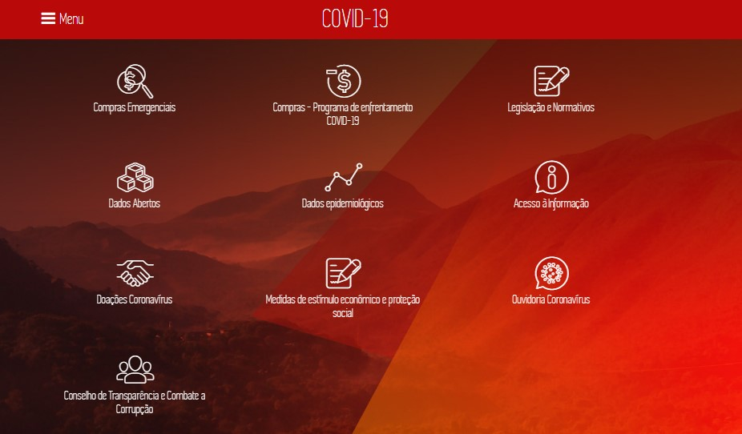

#### **Texto dos ícones:**

- Compras Emergenciais: Acesse as informações relativas aos Contratos Emergenciais firmados para aquisição de bens, serviços, inclusive de engenharia, obras, alienações e locações para enfrentamento da COVID-19, com base na Lei Federal nº 13.979/2020 e na Lei Estadual nº 23.640/2020.
- Contratos - Programa Enfrentamento COVID- 19: Acesse as contratações e os contratos do Programa 26 - Enfrentamento dos efeitos da pandemia da COVID-19.
- Legislação e Normativos: Acesse a legislação e os normativos relativos às medidas de prevenção e combate à COVID- 19.
- Ouvidoria: Registre aqui as denúncias, reclamações e manifestações sobre o enfrentamento a COVID-19.
- Acesso à Informação: Registre sua solicitação de acesso à informação para órgãos e entidades do Poder Executivo Estadual.
- Dados Abertos: Acesse os conjuntos de dados relacionados a COVID 19.
- Conselho de Transparência e Combate a Corrupção: Acesse as informações sobre o Conselho e sua atuação no monitoramento e avaliação das ações relacionadas ao enfrentamento da COVID-19.
- Dados epidemiológicos: Acesse as informações relativas ao boletim epidemiológicos, painel de monitoramento de casos, orientações para o cidadão e outros dados relacionados ao coronavírus divulgadas pela Secretaria de Estado da Saúde.
- Doações: Encontre aqui orientações sobre como fazer doações, informações sobre as doações recebidas e sua destinação;
- Medidas de estímulo econômico e proteção social: Encontre aqui informações sobre as medidas de estímulo econômicas e sociais desenvolvidas no combate a pandemia causada pela COVID-19.

#### **Texto Página Inicial**

*TEXTO DEVERÁ SER ADICIONADO/ALTERADO PELA DTA*

Com foco no fomento da transparência e melhores práticas para atender ao cidadão, o Estado de Minas Gerais disponibiliza seção específica para divulgar dados referentes à COVID-19 no estado de Minas.

As informações disponíveis são relativas a:

- Compras emergenciais realizadas com base na Lei Federal nº 13.979/2020 e na Lei Estadual nº 23.640/2020;
- Compras - Programa de Enfrentamento Covid-19: compras executadas no Programa 26 – Programa de Enfrentamento dos Efeitos da Pandemia de Covid-19, conforme Lei estadual nº 23.632/2020;
- Legislação e Normativos relacionados às medidas de proteção e combate à COVID-19;
- Dados Abertos: todos os conjuntos de dados relacionados a COVID-19 ;
- Conselho de Transparência e Combate à Corrupção: informações sobre o Conselho de Transparência e Combate à Corrupção e sua atuação no monitoramento e avaliação das ações relacionadas ao enfrentamento da COVID-19;
- Dados Epidemiológicos: informações relativas ao boletim epidemiológicos, painel de monitoramento de casos, orientações para o cidadão e outros dados relacionados ao coronavírus divulgadas pela Secretaria de Estado da Saúde;
- Doações: orientações sobre como fazer doações, informações sobre as doações recebidas e sua destinação; e
- Medidas de estímulo econômico e proteção social: informações sobre as medidas de estímulo econômicas e sociais desenvolvidas no combate a pandemia causada pela COVID-19.

É possível, ainda, solicitar informações relativas à pandemia por meio do Acesso à Informação e realizar denúncias, reclamações e sugestões por meio do canal exclusivo da Ouvidoria.

As informações sobre as contratações e aquisições para enfrentar a emergência de saúde pública decorrente da pandemia da COVID-19 estão dispostas no Portal de Transparência de três formas, para conhecê-las clique aqui.

E caso deseje mais informações, solicite por meio do Acesso à Informação.

### 1. Consulta Compras Emergenciais

(inicio)

Link: http://dados.mg.gov.br/dataset/compras-emergenciais-covid-19

### 2. Consulta Compras - Programa de enfrentamento COVID-19

(inicio)

Ao clicar em **[Compras - Programa de enfrentamento COVID-19]** o portal exibe uma página com o painel das contratações relacionados ao Programa 26 - “Enfrentamento dos efeitos da pandemia de COVID-19”.

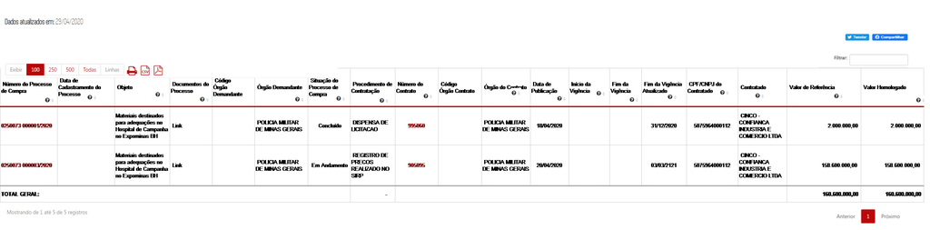

Arquivo .xls: [leiaute-tabelas-covid19](https://github.com/transparencia-mg/especificacoes-portal-transparencia/blob/feat/consulta-contratos-covid/static/leiaute-tabelas-covid19.xlsx)

*Itens da tabela*:

1. **Número do Processo de Compra:** Número identificador do processo de compra no Portal de Compras.
2. **Data de Cadastramento do Processo:** Data de Cadastro do Processo de Compras
3. **Objeto do Processo:** Descrição dos bens e serviços que estão sendo comprados e sua finalidade.
4. **Documentos do Processo:** Relação dos documentos do processo de compra: Edital e suas retificações, relatório de detalhes do processo de compra, dados do pregão e outros arquivos relacionados ao processo.
5. **Código Órgão Demandante:** Código do órgão demandante
6. **Órgão Demandante**: Órgão ou entidade que solicitou a compra de determinado material ou serviço. Pode coincidir ou não com o órgão que está executando o processo de compra.
7. **Situação do Processo:** Situação do processo de compra durante a aquisição de materiais e serviços (concluído, suspenso, em andamento, etc.). Quanto aos processos de compra com situação em andamento, são considerados apenas os itens já homologados desses processos.
8. **Procedimento de Contratação:** Inclui as modalidades de licitação (concorrência, tomada de preços, convite e leilão), pregão, dispensa, inexigibilidade, registro de preços, etc.
9. **Número do Contrato**: Número do contrato registrado no SIAFI.
10. **Código Órgão Contrato:** Código do órgão responsável pelo contrato.
11. **Órgão Contrato**: Órgão ou entidade que formalizou o instrumento de contratação.
12. **Data da Publicação:** Data de Publicação do Contrato no IOF.
13. **Início da Vigência:** Ínicio da vigência do Contrato
14. **Fim da Vigência:**: Data fim da vigência do Contrato.
15. **Fim da Vigência Atualizada:**: Data atualizada do fim da vigência do Contrato.
16. **CPF/CNPJ do Contratado:** Número de identificação do fornecedor. Pessoa Jurídica (CNPJ) e Pessoa física (CPF).
17. **Contratado:** Nome da pessoa física ou jurídica contratada para prestar um serviço ou entregar bens materiais ao Estado.
18. **Valor de Referência**:Valor estimado de um determinado bem ou serviço, obtido por meio de pesquisa de mercado ou cadastro de preços.
19. **Valor Homologado**: Valor final licitado ou comprado.

#### Observações Importantes

- O campo filtro deverá buscar qualquer item na tabela;
- O Painel deverá apresentar todos os processos de compras relacionados ao Programa 026 -Enfrentamento dos Efeitos da Pandemia de COVID-19 independente da situação e do ano de cadastro do processo de compra.  
  **Exemplo:**
  - Processo de Compra Concluido: [0250073 000001/2020](http://transparencia.mg.gov.br/compras-e-patrimonio/compras-e-contratos/comprasecontratos-detalhe-proccompra/2020/20200101/20201231/322109)
  - Processo de Compra ano 2017: [1401189 000001/2017](http://transparencia.mg.gov.br/compras-e-patrimonio/compras-e-contratos/comprasecontratos-detalhe-proccompra/2017/20170101/20171231/90432)
- O painel deve apresentar todos os processos independentemete de haver ou não execução (empenho). *Luiz irá verificar essa possibilidade*
- Ao clicar no *[Número do processo de compra]* o usuário será direcionado a página de detalhamento do Portal que apresenta os dados do processo de compra.  
  **Exemplo:** Processo de compra - [0250073 000001/2020](http://transparencia.mg.gov.br/compras-e-patrimonio/compras-e-contratos/comprasecontratos-detalhe-proccompra/2020/20200101/20201231/322109)
- Ao clicar no *[Número do contrato]* o usuário será direcionado para a página do Portal de Compras para realizar o download do contrato;  
  **Exemplo:** Número do Contrato - [9245761](https://www1.compras.mg.gov.br/contrato/gestaocontratos/arquivosContrato.html?idContrato=162593)
- Ao clicar em *[Documentos do processo]* o usuário será direcionado para a página do Portal de Compras onde constam todos os documentos relacionados ao processo de compra.

  **Exemplo:** Documentos do processo - [Link](https://www1.compras.mg.gov.br/processocompra/processo/consultaProcessoCompra.html?metodo=pesquisar&codigoUnidadeCompra=1501561&numero=000028&ano=2020)
  - *URL* que deverá ser recuperada para exibição dos documentos do processos: [https://www1.compras.mg.gov.br/processocompra/processo/consultaProcessoCompra.html?metodo=pesquisar&codigoUnidadeCompra={unidade}&numero={numero}&ano={ano}](https://www1.compras.mg.gov.br/processocompra/processo/consultaProcessoCompra.html?metodo=pesquisar&codigoUnidadeCompra=%7Bunidade%7D&numero=%7Bnumero%7D&ano=%7Bano%7D)
  - Considerar os seguintes campos para construção da *url*:
  - Processo de Compra: 1501561 000028/2020  
    Código da Unidade: 1501561  
    Número do Processo: 000028  
    Ano do Processo: 2020
- O cidadão poderá realizar a extração dos dados através dos ícones (imprimir, CSV e PDF);
- As colunas da tabela deverão ser movíveis, conforme adotado pelas demais consultas do Portal.
- O usuário poderá classificar os dados da tabela, conforme o adotado pelas demais consultas do Portal.

### 2. Consulta Legislação e Normativos

(inicio)

Ao clicar no ícone *[Legislação e Normativos ]* o portal exibe a página de conteúdo Legislação e Normativos COVID-19 (eg. Voos do Governador).

O conteúdo dessa página será alimentado pela CGE atravéz da aréa administrativa do Portal (Joomla).

[figure not shown]

### 3. Consulta Dados Abertos

(inicio)

Ao clicar no ícone *[Dados Abertos]* o portal exibe o conjunto de dados do Estado referente ao enfrentamento da emergência de saúde pública de importância internacional decorrente do coronavírus.

Link: http://dados.mg.gov.br/dataset?tags=coronavirus

### 4. Consulta Conselho de Transparência e Combate a Corrupção

(inicio)

Ao clicar no ícone *[Conselho de Transparência e Combate a Corrupção]* o portal exibe informações sobre o Conselho de Transparência e Combate à Corrupção e sua atuação no monitoramento e avaliação das ações relacionadas ao enfrentamento da COVID-19.

Link: http://portaldosconselhos.cge.mg.gov.br/

### 5. Ouvidoria

(inicio)

Ao clicar no ícone *[Ouvidoria Coronavírus]* o portal exibe a página de conteúdo da Ouvidoria.

O conteúdo dessa página será alimentado pela CGE através da área administrativa do Portal (Joomla).

[figure not shown]

### 6. Acesso à Informação

(inicio)

Ao clicar no ícone *[Acesso à Informação]* o portal exibe o portal exibe a página de conteúdo do Sistema Eletrônico de Acesso à Informação (e-Sic)

[figure not shown]

### 7. Dados epidemiológicos

(inicio)

Ao clicar no ícone *[Dados epidemiológicos]* o portal exibe a página da Secretaria de Estado da Saúde

link: https://www.saude.mg.gov.br/coronavirus

### 8. Doações

(inicio)

Ao clicar no ícone *[Doações ]* o portal exibe a página de conteúdo Doações COVID-19 (eg. Voos do Governador).

O conteúdo dessa página será alimentado pela CGE através da área administrativa do Portal (Joomla).

[figure not shown]

### 9. Medidas de estímulo econômico e proteção social

(inicio)

Criar uma página de conteúdo *[Medidas de estímulo econômico e proteção social]*.

O conteúdo dessa página será alimentado pela CGE através da área administrativa do Portal (Joomla).

[figure not shown]

# Exemplos / Pesquisa

- [Recomendações Transparência Internacional](https://comunidade.transparenciainternacional.org.br/asset/86:tibr-recomendacoes-de-contratacoes-emergenciais-covid19?stream=1)
- [Alagoas](http://www.alagoascontraocoronavirus.al.gov.br/)
- [Ceará](https://coronavirus.ceara.gov.br/)
- [Espirito Santo](https://coronavirus.es.gov.br/)